# Risk Factor Analysis

## Outcome Variable

**Outcome Variable:** wasted

## Predictor Variables

**Intervention Variable:** nhh

**Adjustment Set:**

- arm
- W_mage
- meducyrs
- feducyrs
- hhwealth_quart
- W_mhtcm
- W_mwtkg
- W_mbmi
- W_nrooms
- cleanck
- impfloor
- impsan
- safeh20
- delta_W_mage
- delta_meducyrs
- delta_feducyrs
- delta_hhwealth_quart
- delta_W_mhtcm
- delta_W_mwtkg
- delta_W_mbmi
- delta_W_nrooms
- delta_cleanck
- delta_impfloor
- delta_impsan
- delta_safeh20

## Stratifying Variables

The analysis was stratified on these variable(s):

- agecat
- studyid
- country

## Data Summary

| agecat | studyid | country | nhh | wasted | n_cell | n |
| --- | --- | --- | --- | --- | --- | --- |
| Birth | IRC | INDIA | 3 or less | 0 | 35 | 343 |
| Birth | IRC | INDIA | 3 or less | 1 | 17 | 343 |
| Birth | IRC | INDIA | 4-5 | 0 | 99 | 343 |
| Birth | IRC | INDIA | 4-5 | 1 | 32 | 343 |
| Birth | IRC | INDIA | 6-7 | 0 | 68 | 343 |
| Birth | IRC | INDIA | 6-7 | 1 | 16 | 343 |
| Birth | IRC | INDIA | 8+ | 0 | 49 | 343 |
| Birth | IRC | INDIA | 8+ | 1 | 27 | 343 |
| Birth | NIH-Birth | BANGLADESH | 3 or less | 0 | 63 | 575 |
| Birth | NIH-Birth | BANGLADESH | 3 or less | 1 | 41 | 575 |
| Birth | NIH-Birth | BANGLADESH | 4-5 | 0 | 175 | 575 |
| Birth | NIH-Birth | BANGLADESH | 4-5 | 1 | 69 | 575 |
| Birth | NIH-Birth | BANGLADESH | 6-7 | 0 | 95 | 575 |
| Birth | NIH-Birth | BANGLADESH | 6-7 | 1 | 35 | 575 |
| Birth | NIH-Birth | BANGLADESH | 8+ | 0 | 74 | 575 |
| Birth | NIH-Birth | BANGLADESH | 8+ | 1 | 23 | 575 |
| Birth | NIH-Crypto | BANGLADESH | 3 or less | 0 | 76 | 707 |
| Birth | NIH-Crypto | BANGLADESH | 3 or less | 1 | 27 | 707 |
| Birth | NIH-Crypto | BANGLADESH | 4-5 | 0 | 236 | 707 |
| Birth | NIH-Crypto | BANGLADESH | 4-5 | 1 | 82 | 707 |
| Birth | NIH-Crypto | BANGLADESH | 6-7 | 0 | 131 | 707 |
| Birth | NIH-Crypto | BANGLADESH | 6-7 | 1 | 36 | 707 |
| Birth | NIH-Crypto | BANGLADESH | 8+ | 0 | 92 | 707 |
| Birth | NIH-Crypto | BANGLADESH | 8+ | 1 | 27 | 707 |
| Birth | PROVIDE | BANGLADESH | 3 or less | 0 | 81 | 532 |
| Birth | PROVIDE | BANGLADESH | 3 or less | 1 | 22 | 532 |
| Birth | PROVIDE | BANGLADESH | 4-5 | 0 | 189 | 532 |
| Birth | PROVIDE | BANGLADESH | 4-5 | 1 | 60 | 532 |
| Birth | PROVIDE | BANGLADESH | 6-7 | 0 | 92 | 532 |
| Birth | PROVIDE | BANGLADESH | 6-7 | 1 | 22 | 532 |

[output cut: 90 more lines]

The following strata were considered:

- agecat: 24 months, studyid: IRC, country: INDIA
- agecat: 24 months, studyid: LCNI-5, country: MALAWI
- agecat: 24 months, studyid: NIH-Birth, country: BANGLADESH
- agecat: 24 months, studyid: NIH-Crypto, country: BANGLADESH
- agecat: 24 months, studyid: PROVIDE, country: BANGLADESH
- agecat: 6 months, studyid: IRC, country: INDIA
- agecat: 6 months, studyid: LCNI-5, country: MALAWI
- agecat: 6 months, studyid: NIH-Birth, country: BANGLADESH
- agecat: 6 months, studyid: NIH-Crypto, country: BANGLADESH
- agecat: 6 months, studyid: PROVIDE, country: BANGLADESH
- agecat: 6 months, studyid: SAS-FoodSuppl, country: INDIA
- agecat: Birth, studyid: IRC, country: INDIA
- agecat: Birth, studyid: NIH-Birth, country: BANGLADESH
- agecat: Birth, studyid: NIH-Crypto, country: BANGLADESH
- agecat: Birth, studyid: PROVIDE, country: BANGLADESH

### Dropped Strata

Some strata were dropped due to rare outcomes:

- agecat: 6 months, studyid: LCNI-5, country: MALAWI
- agecat: 6 months, studyid: NIH-Birth, country: BANGLADESH
- agecat: 6 months, studyid: NIH-Crypto, country: BANGLADESH
- agecat: 6 months, studyid: PROVIDE, country: BANGLADESH
- agecat: 6 months, studyid: SAS-FoodSuppl, country: INDIA
- agecat: 24 months, studyid: IRC, country: INDIA
- agecat: 24 months, studyid: LCNI-5, country: MALAWI
- agecat: 24 months, studyid: NIH-Crypto, country: BANGLADESH

## Methods Detail

We’re interested in the causal parameters $E[Y_a]$ for all values of $a \in \mathcal{A}$. These parameters represent the mean outcome if, possibly contrary to fact, we intervened to set all units to have $A=a$. Under the randomization and positivity assumptions, these are identified by the statistical parameters $\psi_a=E_W[E_{Y|A,W}(Y|A=a,W)]$. In addition, we’re interested in the mean of $Y$, $E[Y]$ under no intervention (the observed mean). We will estimate these parameters by using SuperLearner to fit the relevant likelihood factors – $E_{Y|A,W}(Y|A=a,W)$ and $p(A=a|W)$, and then updating our likelihood fit using a joint TMLE.

For unadjusted analyses ($W=\{\}$), initial likelihoods were estimated using Lrnr_glm to estimate the simple $E(Y|A)$ and Lrnr_mean to estimate $p(A)$. For adjusted analyses, a small library containing Lrnr_glmnet, Lrnr_xgboost, and Lrnr_mean was used.

Having estimated these parameters, we will then use the delta method to estimate relative risks and attributable risks relative to a prespecified baseline level of $A$.

# Results Detail

## Results Plots

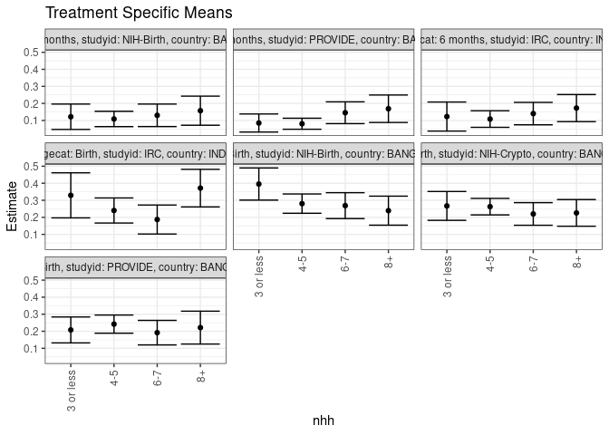

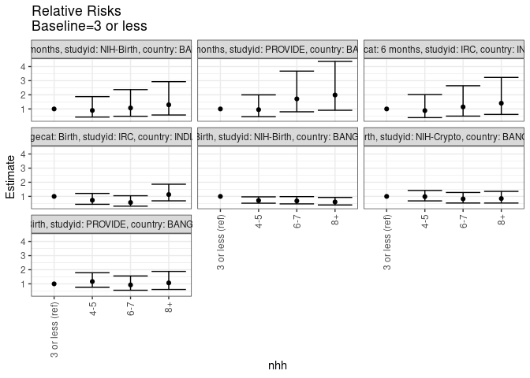

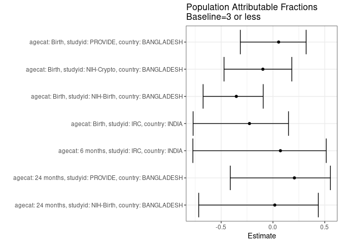

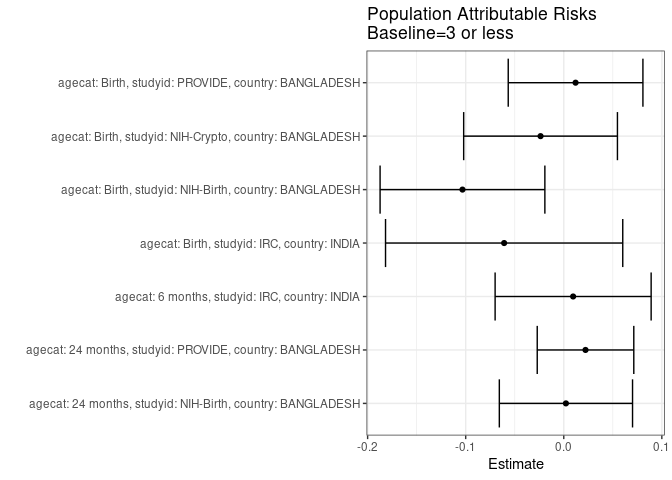

## Results Table

### Parameter: TSM

| agecat | studyid | country | intervention_level | baseline_level | estimate | ci_lower | ci_upper |
| --- | --- | --- | --- | --- | --- | --- | --- |
| Birth | IRC | INDIA | 3 or less | NA | 0.3290197 | 0.1967386 | 0.4613008 |
| Birth | IRC | INDIA | 4-5 | NA | 0.2400997 | 0.1665329 | 0.3136665 |
| Birth | IRC | INDIA | 6-7 | NA | 0.1871261 | 0.1021212 | 0.2721309 |
| Birth | IRC | INDIA | 8+ | NA | 0.3714815 | 0.2611041 | 0.4818588 |
| Birth | NIH-Birth | BANGLADESH | 3 or less | NA | 0.3954564 | 0.3011465 | 0.4897663 |
| Birth | NIH-Birth | BANGLADESH | 4-5 | NA | 0.2804091 | 0.2238342 | 0.3369840 |
| Birth | NIH-Birth | BANGLADESH | 6-7 | NA | 0.2685982 | 0.1926463 | 0.3445501 |
| Birth | NIH-Birth | BANGLADESH | 8+ | NA | 0.2392014 | 0.1540121 | 0.3243907 |
| Birth | NIH-Crypto | BANGLADESH | 3 or less | NA | 0.2669503 | 0.1823019 | 0.3515987 |
| Birth | NIH-Crypto | BANGLADESH | 4-5 | NA | 0.2627768 | 0.2142390 | 0.3113146 |
| Birth | NIH-Crypto | BANGLADESH | 6-7 | NA | 0.2198360 | 0.1534927 | 0.2861792 |
| Birth | NIH-Crypto | BANGLADESH | 8+ | NA | 0.2260340 | 0.1477424 | 0.3043255 |
| Birth | PROVIDE | BANGLADESH | 3 or less | NA | 0.2078810 | 0.1318033 | 0.2839586 |
| Birth | PROVIDE | BANGLADESH | 4-5 | NA | 0.2419765 | 0.1887007 | 0.2952523 |
| Birth | PROVIDE | BANGLADESH | 6-7 | NA | 0.1918472 | 0.1198661 | 0.2638283 |
| Birth | PROVIDE | BANGLADESH | 8+ | NA | 0.2214723 | 0.1250305 | 0.3179142 |
| 6 months | IRC | INDIA | 3 or less | NA | 0.1228070 | 0.0374965 | 0.2081176 |
| 6 months | IRC | INDIA | 4-5 | NA | 0.1082803 | 0.0596149 | 0.1569456 |
| 6 months | IRC | INDIA | 6-7 | NA | 0.1401869 | 0.0743234 | 0.2060504 |
| 6 months | IRC | INDIA | 8+ | NA | 0.1724138 | 0.0929418 | 0.2518858 |
| 24 months | NIH-Birth | BANGLADESH | 3 or less | NA | 0.1216216 | 0.0470650 | 0.1961783 |
| 24 months | NIH-Birth | BANGLADESH | 4-5 | NA | 0.1086957 | 0.0636694 | 0.1537219 |
| 24 months | NIH-Birth | BANGLADESH | 6-7 | NA | 0.1300000 | 0.0640086 | 0.1959914 |
| 24 months | NIH-Birth | BANGLADESH | 8+ | NA | 0.1571429 | 0.0717874 | 0.2424983 |
| 24 months | PROVIDE | BANGLADESH | 3 or less | NA | 0.0849057 | 0.0317962 | 0.1380151 |
| 24 months | PROVIDE | BANGLADESH | 4-5 | NA | 0.0805861 | 0.0482693 | 0.1129028 |
| 24 months | PROVIDE | BANGLADESH | 6-7 | NA | 0.1452991 | 0.0813891 | 0.2092092 |
| 24 months | PROVIDE | BANGLADESH | 8+ | NA | 0.1686747 | 0.0880450 | 0.2493044 |

### Parameter: E(Y)

| agecat | studyid | country | intervention_level | baseline_level | estimate | ci_lower | ci_upper |
| --- | --- | --- | --- | --- | --- | --- | --- |
| Birth | IRC | INDIA | NA | NA | 0.2682216 | 0.2212677 | 0.3151755 |
| Birth | NIH-Birth | BANGLADESH | NA | NA | 0.2921739 | 0.2549711 | 0.3293768 |
| Birth | NIH-Crypto | BANGLADESH | NA | NA | 0.2432815 | 0.2116319 | 0.2749310 |
| Birth | PROVIDE | BANGLADESH | NA | NA | 0.2199248 | 0.1846953 | 0.2551543 |
| 6 months | IRC | INDIA | NA | NA | 0.1323529 | 0.0994307 | 0.1652752 |
| 24 months | NIH-Birth | BANGLADESH | NA | NA | 0.1238318 | 0.0925894 | 0.1550741 |
| 24 months | PROVIDE | BANGLADESH | NA | NA | 0.1070812 | 0.0818727 | 0.1322897 |

### Parameter: RR

| agecat | studyid | country | intervention_level | baseline_level | estimate | ci_lower | ci_upper |
| --- | --- | --- | --- | --- | --- | --- | --- |
| Birth | IRC | INDIA | 3 or less | 3 or less | 1.0000000 | 1.0000000 | 1.0000000 |
| Birth | IRC | INDIA | 4-5 | 3 or less | 0.7297427 | 0.4402631 | 1.2095596 |
| Birth | IRC | INDIA | 6-7 | 3 or less | 0.5687381 | 0.3093463 | 1.0456342 |
| Birth | IRC | INDIA | 8+ | 3 or less | 1.1290554 | 0.6848800 | 1.8612982 |
| Birth | NIH-Birth | BANGLADESH | 3 or less | 3 or less | 1.0000000 | 1.0000000 | 1.0000000 |
| Birth | NIH-Birth | BANGLADESH | 4-5 | 3 or less | 0.7090771 | 0.5190579 | 0.9686595 |
| Birth | NIH-Birth | BANGLADESH | 6-7 | 3 or less | 0.6792106 | 0.4694472 | 0.9827028 |
| Birth | NIH-Birth | BANGLADESH | 8+ | 3 or less | 0.6048742 | 0.3939190 | 0.9288020 |
| Birth | NIH-Crypto | BANGLADESH | 3 or less | 3 or less | 1.0000000 | 1.0000000 | 1.0000000 |
| Birth | NIH-Crypto | BANGLADESH | 4-5 | 3 or less | 0.9843660 | 0.6816767 | 1.4214603 |
| Birth | NIH-Crypto | BANGLADESH | 6-7 | 3 or less | 0.8235090 | 0.5314723 | 1.2760160 |
| Birth | NIH-Crypto | BANGLADESH | 8+ | 3 or less | 0.8467268 | 0.5289056 | 1.3555277 |
| Birth | PROVIDE | BANGLADESH | 3 or less | 3 or less | 1.0000000 | 1.0000000 | 1.0000000 |
| Birth | PROVIDE | BANGLADESH | 4-5 | 3 or less | 1.1640147 | 0.7598292 | 1.7832038 |
| Birth | PROVIDE | BANGLADESH | 6-7 | 3 or less | 0.9228705 | 0.5475059 | 1.5555813 |
| Birth | PROVIDE | BANGLADESH | 8+ | 3 or less | 1.0653806 | 0.6034372 | 1.8809508 |
| 6 months | IRC | INDIA | 3 or less | 3 or less | 1.0000000 | 1.0000000 | 1.0000000 |
| 6 months | IRC | INDIA | 4-5 | 3 or less | 0.8817106 | 0.3854765 | 2.0167604 |
| 6 months | IRC | INDIA | 6-7 | 3 or less | 1.1415220 | 0.4934812 | 2.6405719 |
| 6 months | IRC | INDIA | 8+ | 3 or less | 1.4039409 | 0.6099352 | 3.2315727 |
| 24 months | NIH-Birth | BANGLADESH | 3 or less | 3 or less | 1.0000000 | 1.0000000 | 1.0000000 |
| 24 months | NIH-Birth | BANGLADESH | 4-5 | 3 or less | 0.8937198 | 0.4264662 | 1.8729153 |
| 24 months | NIH-Birth | BANGLADESH | 6-7 | 3 or less | 1.0688889 | 0.4822491 | 2.3691564 |
| 24 months | NIH-Birth | BANGLADESH | 8+ | 3 or less | 1.2920635 | 0.5696110 | 2.9308213 |
| 24 months | PROVIDE | BANGLADESH | 3 or less | 3 or less | 1.0000000 | 1.0000000 | 1.0000000 |
| 24 months | PROVIDE | BANGLADESH | 4-5 | 3 or less | 0.9491249 | 0.4514740 | 1.9953266 |
| 24 months | PROVIDE | BANGLADESH | 6-7 | 3 or less | 1.7113010 | 0.7965823 | 3.6763953 |
| 24 months | PROVIDE | BANGLADESH | 8+ | 3 or less | 1.9866131 | 0.9040947 | 4.3652855 |

### Parameter: PAR

| agecat | studyid | country | intervention_level | baseline_level | estimate | ci_lower | ci_upper |
| --- | --- | --- | --- | --- | --- | --- | --- |
| Birth | IRC | INDIA | 3 or less | NA | -0.0607981 | -0.1817419 | 0.0601457 |
| Birth | NIH-Birth | BANGLADESH | 3 or less | NA | -0.1032825 | -0.1872936 | -0.0192714 |
| Birth | NIH-Crypto | BANGLADESH | 3 or less | NA | -0.0236688 | -0.1020647 | 0.0547270 |
| Birth | PROVIDE | BANGLADESH | 3 or less | NA | 0.0120439 | -0.0566242 | 0.0807120 |
| 6 months | IRC | INDIA | 3 or less | NA | 0.0095459 | -0.0700043 | 0.0890961 |
| 24 months | NIH-Birth | BANGLADESH | 3 or less | NA | 0.0022102 | -0.0657061 | 0.0701264 |
| 24 months | PROVIDE | BANGLADESH | 3 or less | NA | 0.0221755 | -0.0270517 | 0.0714027 |

### Parameter: PAF

| agecat | studyid | country | intervention_level | baseline_level | estimate | ci_lower | ci_upper |
| --- | --- | --- | --- | --- | --- | --- | --- |
| Birth | IRC | INDIA | 3 or less | NA | -0.2266713 | -0.7707763 | 0.1502470 |
| Birth | NIH-Birth | BANGLADESH | 3 or less | NA | -0.3534966 | -0.6741876 | -0.0942340 |
| Birth | NIH-Crypto | BANGLADESH | 3 or less | NA | -0.0972899 | -0.4721157 | 0.1820988 |
| Birth | PROVIDE | BANGLADESH | 3 or less | NA | 0.0547635 | -0.3149661 | 0.3205361 |
| 6 months | IRC | INDIA | 3 or less | NA | 0.0721248 | -0.7730496 | 0.5144228 |
| 24 months | NIH-Birth | BANGLADESH | 3 or less | NA | 0.0178480 | -0.7166926 | 0.4380925 |
| 24 months | PROVIDE | BANGLADESH | 3 or less | NA | 0.2070907 | -0.4121232 | 0.5547802 |